# Introduction to Power Analysis with R - AcqVA Aurora workshop

Martin Schweinberger

2022-01-20

[figure not shown]

# Introduction

This tutorial introduces power analysis for determining sample size using R with the aim of informing about the theoretical underpinnings, showcasing how to perform power analysis, and enabling participants on how to adapt, change, and modify data sets so that they can be fed into a power analysis using the `simr` (Green and MacLeod 2016a).

[figure not shown]

This tutorial is aimed at intermediate users of R. The aim is not to provide a fully-fledged guide but rather to show and exemplify how to perform a power analysis for a generalized linear mixed-effects modelas this is the most common type of analysis for experimental studies.

The entire R Notebook for the tutorial can be downloaded [**here**](https://github.com/MartinSchweinberger/AcqVA_DataVisR_WS/introviz.Rmd). If you want to render the R Notebook on your machine, i.e. knitting the document to html or a pdf, you need to make sure that you have R and RStudio installed and you also need to download the [**bibliography file**](https://github.com/MartinSchweinberger/AcqVA_DataVisR_WS/bibliography.bib) and store it in the same folder where you store the Rproj file.  
**[Here](https://colab.research.google.com/drive/1Ty2jK_JZo9hANAWXg-d_PRV8dKVx4P51?usp=sharing)** is a **link to an interactive version of this tutorial on Google Colab**. The interactive tutorial is based on a Jupyter notebook of this tutorial. This interactive Jupyter notebook allows you to execute code yourself and - if you copy the Jupyter notebook - you can also change and edit the notebook, e.g. you can change code and upload your own data.

## What to do before the workshop

To get the most out of this workshop, you will need to have some (basic) R skills and (basic) knowledge of how to work with R, RStudio, R Projects, and R Notebooks. If you have no or little experience with this or if you need to refresh your skills, please carefully read (or optimally go through) these tutorials:

- [Getting started with R](https://slcladal.github.io/intror.html)
- [Handling tables in R](https://slcladal.github.io/table.html)

Before attending the workshop, you need to install the following packages in RStudio:

- `here` (for easy pathing)
- `tidyverse` (for data processing)
- `pwr` (for simple power analyses)
- `simr` (for power analyses for glmms)
- `knitr` (for knitting R Notebooks)
- `markdown` (for rendering Rmd files)
- `rmarkdown` (for R Markdown formatting)
- `installr` (for updating R)

You can update R and install these packages by clicking on `packages` on the top of the lower right pane in RStudio or you can execute the following code in the lower left, `Console` pane of RStudio.

```r
# update R
#install.packages("installr")
#library(installr)
#updateR()
# install required packages
install.packages(c("tidyverse", "here",  "pwr", "lme4", "sjPlot", "simr"),
                 dependencies = T)
```

**It is really important that you have knowledge of R and RStudio and that you have installed the packages before the workshop so that we do not have to deal with technical issues too much.**

You can find a more detailed version of the content of this workshop in these two LADAL tutorials

- [Power Analysis with R](https://slcladal.github.io/pwr.html)

You can follow this workshop in different ways - you can sit back and watch it like a lecture or take a more active role - that said, the intention for this workshop is clearly to be practical so that I show something and then you do it on you computer and we have exercises where you can try out what you have just learned.

So, in essence, there are the following three options for following this workshop:

1. You can sit back and enjoy and focus on what you see and then go back home and try it by yourself later.
2. You can follow this workshop in RStudio and execute code, see what it does, understand it, and adapt it. This requires some skills in R and RStudio - although I have trued to keep things simple.
3. You can click on this link which takes you to a Jupyter Notebook on Google Colab (and you are then ready to go - you only have to install the packages which takes a couple of minutes). You can then copy that Notebook and save it in your own Google Drive and then execute code, modify it, and understand it. This does require less skills and will be easier for people who just want to focus on the code that produces certain visualizations without doing it in RStudio. Also, this get rid of most technical issues (hopefully) but the installation of packages will take a while and you will need to re-install the packages every time you want to re-use the Jupyter Notebook.

Choose which option suits you best and then go with it.

## Timeline

Here is what we have planned to cover in this workshop:

Tuesday, January 25, 10-12am

- Introduction
- Primer
- Session preparation
- How to load different data formats into R
- Basics of data preparation
- Getting started with pwr
- Getting started with simr

Tuesday, January 25, 1-3pm

- Simulating data
- Simulating models
- Application of power analyses for mixed-effect models
- Wrap-up and Resources

# Getting started

If you choose option 2, you need to set up our R session and prepare our R project at the very beginning of the workshop.

For everything to work, please do the following:

- Create a folder for this workshop somewhere on your computer, e.g. called *AcqVA_DataVisR_WS*
- In that folder, create two subfolders called *data* and *images*
- Open RStudio, go to File > New Project > Existing Directory (Browse to project folder) > Create (and hit Enter)

This will then create an R Project in the project folder.

## Primer

We start by creating a very simple graph in base R just to get you going and showing you that creating graphs can be very easy.

So for your first graph, we will create some data and then visualize it - we do this in the following code chunk.

To execute the code, simply click on the *Play* button in the top right corner of the code box.

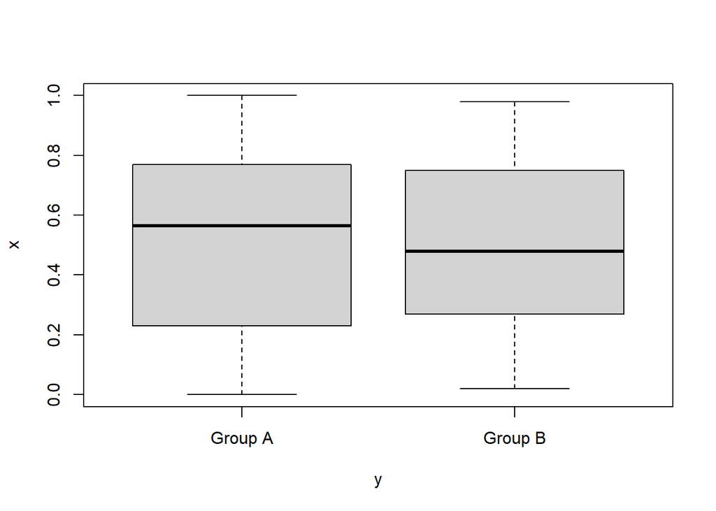

```r
# generate two variables (x and y)
x <- sample(seq(0, 1, 0.01), 100) # draw a sample of 100 from numbers between 0 and 1
y <- rep(c("Group A", "Group B"), each = 50) # create a vector of 100 representing 2 groups
# create a box plot
boxplot(x ~ y)
```

Yay! You created a nice boxplot in R. As you can see, generating graphs in R can be super simple.

But the boxplot does not really look nice and fancy, does it? Well, have a look at the next code chunk, think about what it does and then execute it by clicking on *play*.

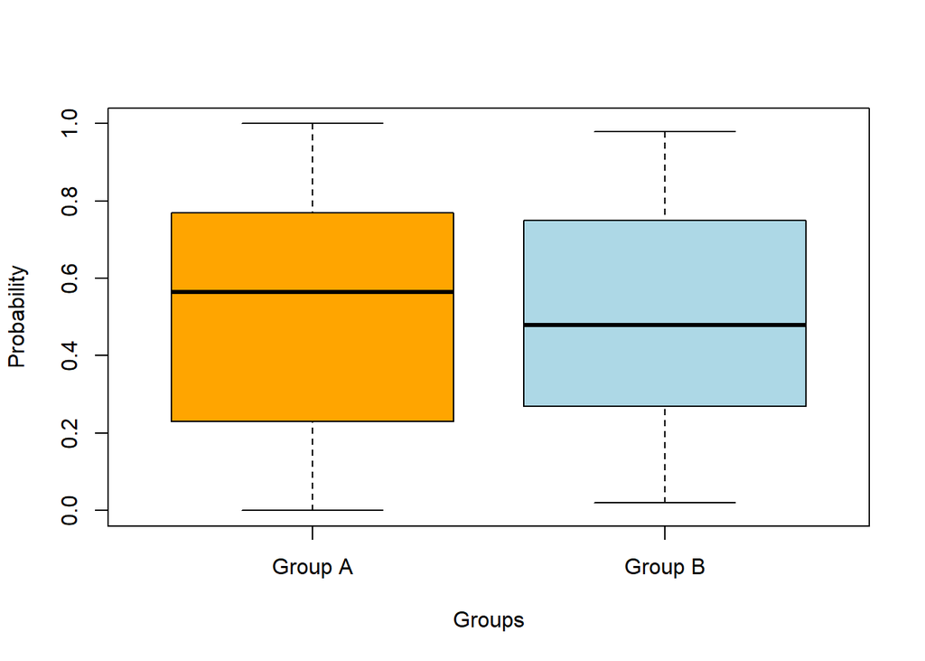

```r
# create a nicer box plot
boxplot(x ~ y,
        col = c("orange", "lightblue"), # define colors of boxes
        xlab = "Groups",                # define x-axis label
        ylab = "Probability")           # define y-axis label
```

And you can use base R to create graphs! In this tutorial, I want to show you how to generate graphs that are prettier but the code is also a bit more complex. Bute before we get to that, let’s briefly talk about the data we will be using.

## Today’s Data

We will use 3 data sets, two data sets that Yulia provided and one that was send in by Isabel. The publications associated with the data are:

The Accent data (already published):

Kupisch, Tanja, Nadine Kolb, Yulia Rodina, and Olga Urek. 2021. Foreign Accent in Pre- and Primary School Heritage Bilinguals. *Languages* 6(2), 96; https://doi.org/10.3390/languages6020096

And the L2 English intervention data (which is still in progress):

Nygaard, Maren, Chistopher Loe Olsen, and Yulia Rodina. In progress. The effect of form-focused intervention on subject-verb agreement in L1 Norwegian L2 English learners.

In addition, we will use a data set that is part of the `likert` package and a data set that Isabel provided for the mixed-model effects visualization.

Here are summaries of the data sets:

1. **`data_german`** (we will call this data ``myxlsx`): contains 777 observations of the following 8 variables:
- ID_rater: 21 levels
- ID_child: 37 levels
- age_group: 2 levels, namely *preschool*, *school* and missing (NA, n = 21, 2.70%)
- accent_response: 3 levels, namely *no* (no accent), *s* (strong accent), *w* (weak accent) and missing (NA, n = 22, 2.83%)
- accent_numeric: n = 777, Mean = 0.81, SD = 0.77 (0 = no accent, 1 = weak accent, 2 = strong accent)
- rating_language: 1 level, namely DE (n = 777)
- age_months: n = 777, Mean = 80.19, SD = 19.99
- family: 3 levels, namely *bil-mixed* (bilingual - no dominance), *bil-rus* (bilingual - Russian dominant), and *mono-de* (monolingual German)
2. **`L2EnglishIntervention`** (we will call this data `exdata`): contains 3072 observations of the following 14 variables:
- …1: n = 3072 (Mean = 1536.50, SD = 886.95)
- Test-item: n = 3072 (Mean = 24.50, SD = 13.86)
- ID: 32 levels
- Age: n = 3072 (Mean = 16.00, SD = 0.00)
- L1: 1 level, namely *Norwegian* (n = 3072)
- L2: 1 level, namely *English* (n = 3072)
- Proficiency-max39: n = 3072 (Mean = 31.52, SD = 4.58)
- Group: 2 levels, namely Kontroll (n = 1536, 50.00%) and Test (n = 1536, 50.00%)
- Test: 2 levels, namely Post-test (n = 1536, 50.00%) and Pre-test (n = 1536, 50.00%)
- Response: 2 levels, namely Feil (n = 1370, 44.60%) and Riktig (n = 1702, 55.40%)
- Respose-code: n = 3072 (Mean = 0.76, SD = 0.43)
- Grammaticality: 2 levels, namely *Grammatical* (n = 1536) and *Ungrammatical* (n = 1536)
- Condition: 5 levels, namely *AGR_LOC_PL* (n = 512), *AGR_LOC_SG* (n = 512), *AGR_LONG_PL* (n = 512), *AGR_LONG_SG* (n = 512) and *FILLER* (n = 1024)
- Sentence: 48 levels
3. **`AJT_V2`** (we will call this data `regdata`: contains 2103 observations of the following 14 variables:
- ID: n = 2103 (0% missing)
- Version: n = 2103 (Mean = 11.53, SD = 5.44)
- Task.Name: 1 level, namely *AJT*
- Response: 2 levels, namely Bad (n = 841, 39.99%) and Good (n = 1262, 60.01%)
- Response_num: n = 2103 (Mean = 0.60, SD = 0.49)
- Sentence: 24 levels
- Group: 2 levels, namely *English* (n = 1193) and *Norwegian-English* (n = 910)
- Word_order: 2 levels, namely *V2* (n = 1054) and *V3* (n = 1049)
- Num: n = 2103 (Mean = 8.41, SD = 5.2)
- Sentence_type: 2 levels, namely *Non-subject-initial* (n = 1053) and *Sentence adverbials* (n = 1050)
- Gender: 2 levels, namely *Female* (n = 1601) and *Male* (n = 502)
- Age: n = 2103 (Mean = 32.43, SD = 12.07)
- Acc: n = 2103 (Mean = 0.23, SD = 0.42)
- Condition: 4 levels, namely *AdverbV2* (n = 528), *AdverbV3* (n = 525), *TopV2* (n = 526) and *TopV3* (n = 524)

The basis for the present tutorial is Green and MacLeod (2016b) (which you can find [here](https://besjournals.onlinelibrary.wiley.com/doi/full/10.1111/2041-210X.12504)). Green and MacLeod (2016b) is a highly recommendable and thorough tutorial on performing power analysis in R. Recommendable literature on this topic are, e.g. Arnold et al. (2011) and Johnson et al. (2015) and [this tutorial](https://www.journalofcognition.org/articles/10.5334/joc.10/).

**NOTE**  
Power analysis have also been used post-hoc to test if the sample size of studies was sufficient to detect meaningful effects. However, such post-hoc power calculations where the target effect size comes from the data, give misleading results (Hoenig and Heisey 2001; Perugini, Gallucci, and Costantini 2018) and should thus be treated with extreme care!

## What determines if you find an effect?

There are different factors that determine if a model finds an effect. The accuracy (i.e., the probability of finding an effect) depends on three main factors:

- the size of the effect (bigger effects are easier to detect)
- the variability of the effect (less variability makes it easier to detect an effect), and
- the sample size (the bigger the sample size, the easier it is to detect an effect);
  - number of subjects/participants
  - number of items/questions
  - number of observations per item within subjects/participants

Now, if a) we dealing with a very big effect, then we need only few participants and few items to accurately find this effect.

Or b) if we dealing with an effect that has low variability (it is observable for all subjects with the same strength), then we need only few participants and few items to accurately find this effect.

Before we conduct a study, we should figure out, what sample we need to detect a small/medium effect with medium variability so that our model is sufficient to detect this kind of effect. In order to do this, we would generate a data set that mirrors the kind of data that we expect to get (with the properties that we expect to get). We can then fit a model to this data and check if a model would be able to detect the expected effect. However, because a single model does not tell us that much (ift could simply be luck that it happened to find the effect), we run many different models on variations of the data and see how many of them find the effect. As a general rule of thumb, we want a data set that allows a model to find a medium sized effect with at least an accuracy of 80 percent (Field et al. 2007).

In the following, we will go through how to determine what sample size we need for an example analysis.

## Preparation and session set up

This tutorial is based on R. If you have not installed R or are new to it, you will find an introduction to and more information how to use R [here](https://slcladal.github.io/intror.html). For this tutorials, we need to install certain *packages* into the R *library* on your computer so that the scripts shown below are executed without errors. Before turning to the code below, please install the packages by running the code below this paragraph. If you have already installed the packages mentioned below, then you can skip ahead and ignore this section. To install the necessary packages, simply run the following code - it may take some time (between 1 and 5 minutes to install all of the libraries so you do not need to worry if it takes some time).

```r
# install libraries
install.packages(c("tidyverse", "lme4", "sjPlot", "simr"))
install.packages(c("DT", "knitr", "flextable"))
```

Now that we have installed the packages, we can activate them as shown below.

```r
# set options
options(stringsAsFactors = F)         # no automatic conversion of factors
options("scipen" = 100, "digits" = 4) # suppress math annotation
options(max.print=1000)               # print max 1000 results
# load packages
library(tidyverse)
library(lme4)
library(sjPlot)
library(simr)
library(DT)
library(knitr)
library(flextable)
```

Once you have installed R and RStudio and initiated the session by executing the code shown above, you are good to go.

## Generating data

In order to perform a power analysis, we will start by loading the tidyverse package to process the data and by generating a data that we will use to determine the power of a regression model.

This simulated data set has

- 200 data points
- 2 Conditions (Control, Test)
- 10 Subjects
- 10 Items

```r
# generate data
simdat <- data.frame(
  sub <- rep(paste0("Sub", 1:10), each = 20),
  cond <- rep(c(
    rep("Control", 10),
    rep("Test", 10))
    , 10),
  itm <- as.character(rep(1:10, 20))
) %>%
  dplyr::rename(Subject = 1,
                Condition = 2,
                Item = 3) %>%
  dplyr::mutate_if(is.character, factor)
```

Table 0.1: First 15 rows of simdat.

| Subject | Condition | Item |
| --- | --- | --- |
| Sub1 | Control | 1 |
| Sub1 | Control | 2 |
| Sub1 | Control | 3 |
| Sub1 | Control | 4 |
| Sub1 | Control | 5 |
| Sub1 | Control | 6 |
| Sub1 | Control | 7 |
| Sub1 | Control | 8 |
| Sub1 | Control | 9 |
| Sub1 | Control | 10 |
| Sub1 | Test | 1 |
| Sub1 | Test | 2 |
| Sub1 | Test | 3 |
| Sub1 | Test | 4 |
| Sub1 | Test | 5 |

We add a dependent variable (AOI) which represents the dependent variable in the study. In our case, we determine that Condition has a relatively weak effect (the probability of gazing into the area of interest (AOI) is .7 in the test condition compared to .5 in the control condition). In addition, this effect is only present in half of the subjects to reflect the variability in the effect.

```r
simdat <- simdat %>%
  dplyr::arrange(Condition) %>%
  dplyr::mutate(
  dep <- c(sample(c("AOI", "NotAOI"), 50, replace = T, prob = c(.5, .5)),
           sample(c("AOI", "NotAOI"), 50, replace = T, prob = c(.5, .5)),
           sample(c("AOI", "NotAOI"), 50, replace = T, prob = c(.5, .5)),
           sample(c("AOI", "NotAOI"), 50, replace = T, prob = c(.7, .3)))
  ) %>%
  dplyr::mutate_if(is.character, factor) %>%
  dplyr::rename(AOI = 4)
```

The data looks like this.

| Subject | Condition | Item | AOI |
| --- | --- | --- | --- |
| Sub1 | Control | 1 | NotAOI |
| Sub1 | Control | 2 | NotAOI |
| Sub1 | Control | 3 | NotAOI |
| Sub1 | Control | 4 | AOI |
| Sub1 | Control | 5 | AOI |
| Sub1 | Control | 6 | AOI |
| Sub1 | Control | 7 | AOI |
| Sub1 | Control | 8 | AOI |
| Sub1 | Control | 9 | NotAOI |
| Sub1 | Control | 10 | AOI |

[output cut: 190 more lines]

# 1 Post-Hoc Power Analysis

Now that we have generated some data, we will fit a model to it and perform a power analysis on the observed effects.

**NOTE**  
Post-hoc power calculations (where the target effect size comes from the data) give misleading results (Hoenig and Heisey 2001; Perugini, Gallucci, and Costantini 2018) and should thus be treated with extreme care!

We will fit a first model to the data. Thus, in a first step, we load the `lme4` package to create a model, set a seed (to save the results and so that the results can be replicated), and then create an initial mixed-effects model.

```r
# set seed for replicability
set.seed(12345)
# fit model
m1 <- glmer(AOI ~ (1|Subject) +(1|Item) + Condition, family="binomial", data=simdat)
# inspect results
summary(m1)
```

```
## Generalized linear mixed model fit by maximum likelihood (Laplace
##   Approximation) [glmerMod]
##  Family: binomial  ( logit )
## Formula: AOI ~ (1 | Subject) + (1 | Item) + Condition
##    Data: simdat
##
##      AIC      BIC   logLik deviance df.resid
##    270.0    283.1   -131.0    262.0      196
##
## Scaled residuals:
##    Min     1Q Median     3Q    Max
## -1.254 -0.718 -0.716  0.799  1.397
##
## Random effects:
##  Groups  Name        Variance Std.Dev.
##  Subject (Intercept) 0.00000  0.0000
##  Item    (Intercept) 0.00127  0.0357
## Number of obs: 200, groups:  Subject, 10; Item, 10
##
## Fixed effects:
##               Estimate Std. Error z value Pr(>|z|)
## (Intercept)      0.447      0.206    2.18  0.02957 *
## ConditionTest   -1.111      0.296   -3.76  0.00017 ***
## ---
## Signif. codes:  0 '***' 0.001 '**' 0.01 '*' 0.05 '.' 0.1 ' ' 1
##
## Correlation of Fixed Effects:
##             (Intr)
## ConditinTst -0.697
## optimizer (Nelder_Mead) convergence code: 0 (OK)
## boundary (singular) fit: see ?isSingular
```

We now check the effect sizes of the predictors in the model. We can do this by displaying the results of the model using the `tab_model` function from the `sjPlot` package.

```r
# tabulate results
sjPlot::tab_model(m1)
```

|  | AOI |  |  |
| --- | --- | --- | --- |
| Predictors | Odds Ratios | CI | p |
| (Intercept) | 1.56 | 1.05 – 2.34 | **0.030** |
| Condition [Test] | 0.33 | 0.18 – 0.59 | **<0.001** |
| Random Effects |  |  |  |
| σ<sup>2</sup> | 3.29 |  |  |
| τ<sub>00</sub> <sub>Subject</sub> | 0.00 |  |  |
| τ<sub>00</sub> <sub>Item</sub> | 0.00 |  |  |
| N <sub>Subject</sub> | 10 |  |  |
| N <sub>Item</sub> | 10 |  |  |
| Observations | 200 |  |  |
| Marginal R<sup>2</sup> / Conditional R<sup>2</sup> | 0.086 / NA |  |  |

Now, we perform power analysis on an observed effect. This analysis tells us how likely the model is to find an observed effect given the data.

**NOTE**  
We use a very low number of simulations (100) and we use the default z-test which is suboptimal for small samples (Bolker et al. 2009). In a proper study, you should increase the number of simulations (to at least 1000) and you should use a bootstrapping rather than a z-test (cf. Halekoh, Højsgaard, and others 2014).

```r
# set seed for replicability
set.seed(12345)
# perform power analysis for present model
rsim0 <- powerSim(m1, fixed("ConditionTest", "z"), nsim=100)
```

Now we can inspect the results.

```r
# inspect results
rsim0
```

```
## Power for predictor 'ConditionTest', (95% confidence interval):
##       97.00% (91.48, 99.38)
##
## Test: z-test
##       Effect size for ConditionTest is -1.1
##
## Based on 100 simulations, (1 warning, 0 errors)
## alpha = 0.05, nrow = 200
##
## Time elapsed: 0 h 0 m 18 s
##
## nb: result might be an observed power calculation
```

The results of the power analysis show that, given the data at hand, the model would have detected the effect of `Conidition:Test` with a probability of 97 percent. However, and as stated above, the results of such post-hoc power calculations (where the target effect size comes from the data) give misleading results (Hoenig and Heisey 2001) and should thus be treated with extreme care!

# 2 Power Analysis of Set Effects

- the size of the effect (bigger effects are easier to detect)
- the variability of the effect (less variability makes it easier to detect an effect), and
- the sample size (the bigger the sample size, the easier it is to detect an effect);
  - number of subjects/participants
  - number of items/questions
  - number of observations per item within subjects/participants

We will now check if the sample size is sufficient to detect a small effect (Cohen’s d 0.2). According to Chen, Cohen, and Chen (2010) odds ratios of 1.68, 3.47, and 6.71 are equivalent to Cohen’s d = 0.2 (small), 0.5 (medium), and 0.8 (large) - the traditional scale is 0.2 for a small, 0.5 for medium sized, and 0.8 for a large or strong effect (cf. also Perugini, Gallucci, and Costantini 2018, 2). We need to determine the odds ratios of the fixed effects and then convert them into Cohen’s d values for which we have associations between traditional denominations (small, medium, and large) and effect size values.

```r
estimatesfixedeffects <- fixef(m1)
exp(estimatesfixedeffects)
```

```
##   (Intercept) ConditionTest
##        1.5643        0.3292
```

```r
# set seed for replicability
set.seed(12345)
# perform power analysis for small effect
fixef(m1)["ConditionTest"] <- 0.519
estimatesfixedeffects <- fixef(m1)
exp(estimatesfixedeffects)
```

```
##   (Intercept) ConditionTest
##         1.564         1.680
```

Now we can test if the sample size of the model is sufficient to find a small effect.

```r
# set seed for replicability
set.seed(12345)
# perform power analysis for present model
rsim1 <- powerSim(m1, fixed("ConditionTest", "z"), nsim=100)
```

The results are shown below.

```r
# show results
rsim1
```

```
## Power for predictor 'ConditionTest', (95% confidence interval):
##       43.00% (33.14, 53.29)
##
## Test: z-test
##       Effect size for ConditionTest is 0.52
##
## Based on 100 simulations, (0 warnings, 0 errors)
## alpha = 0.05, nrow = 200
##
## Time elapsed: 0 h 0 m 18 s
```

The power analysis shows that the data is sufficient to detect a small effect for Condition:Test with 43 percent accuracy.

# 3 Power Analysis of Extended Data

We will now extend the data to see what sample size is needed to get to the 80 percent accuracy threshold. We begin by increasing the number of items from 10 to 30 to see if this would lead to a sufficient sample size.

```r
# increase sample size
m2 <- extend(m1, along="Item", n=30)
# perform power simulation
rsim2 <- powerSim(m2, fixed("ConditionTest", "z"), nsim=100)
```

The results are shown below.

```r
# show results
rsim2
```

```
## Power for predictor 'ConditionTest', (95% confidence interval):
##       81.00% (71.93, 88.16)
##
## Test: z-test
##       Effect size for ConditionTest is 0.52
##
## Based on 100 simulations, (0 warnings, 0 errors)
## alpha = 0.05, nrow = 600
##
## Time elapsed: 0 h 0 m 29 s
```

# 4 Power Analysis for Ranges

We can also check the accuracy for a range of values as shown below. We begin by extending the number of Items.

```r
pc2 <- powerCurve(m2, fixed("ConditionTest", "z"), along = "Item", nsim=100)
```

The results are shown below.

```r
# show results
print(pc2)
```

```
## Power for predictor 'ConditionTest', (95% confidence interval),
## by number of levels in Item:
##       3: 16.00% ( 9.43, 24.68) - 60 rows
##       6: 26.00% (17.74, 35.73) - 120 rows
##       9: 44.00% (34.08, 54.28) - 180 rows
##      12: 55.00% (44.73, 64.97) - 240 rows
##      15: 59.00% (48.71, 68.74) - 300 rows
##      18: 72.00% (62.13, 80.52) - 360 rows
##      21: 77.00% (67.51, 84.83) - 420 rows
##      24: 76.00% (66.43, 83.98) - 480 rows
##      27: 83.00% (74.18, 89.77) - 540 rows
##      30: 86.00% (77.63, 92.13) - 600 rows
##
## Time elapsed: 0 h 3 m 1 s
```

In addition, we can plot the results as follows:

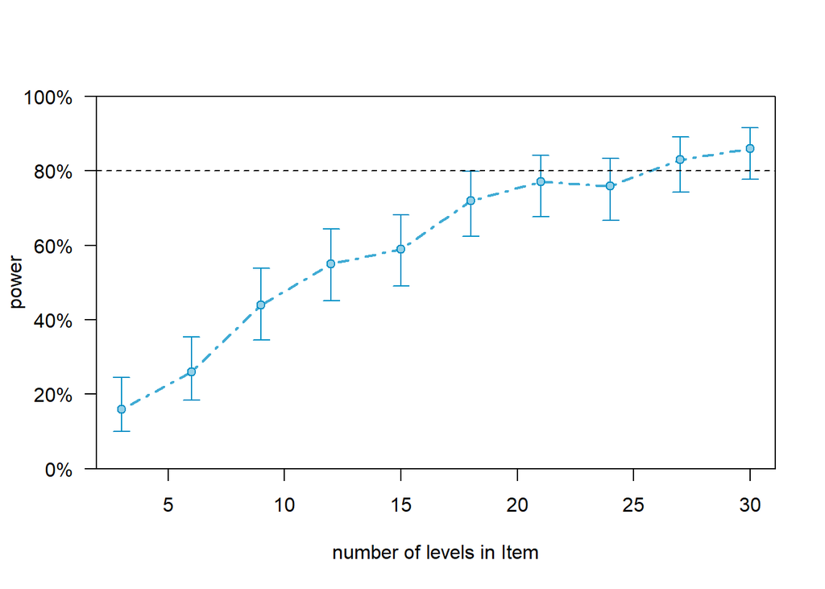

```r
plot(pc2)
```

Instead of increasing the number of Items, we could also increase the number of Subjects. So below, we test check the accuracy for up to 30 subjects.

```r
m3 <- extend(m1, along="Subject", n=30)
# perform power calculation
pc3 <- powerCurve(m3, fixed("ConditionTest", "z"), along="Subject", nsim=100)
```

The results are shown below.

```r
# print results
print(pc3)
```

```
## Power for predictor 'ConditionTest', (95% confidence interval),
## by number of levels in Subject:
##       3: 21.00% (13.49, 30.29) - 60 rows
##       6: 36.00% (26.64, 46.21) - 120 rows
##       9: 36.00% (26.64, 46.21) - 180 rows
##      12: 47.00% (36.94, 57.24) - 240 rows
##      15: 57.00% (46.71, 66.86) - 300 rows
##      18: 66.00% (55.85, 75.18) - 360 rows
##      21: 71.00% (61.07, 79.64) - 420 rows
##      24: 77.00% (67.51, 84.83) - 480 rows
##      27: 82.00% (73.05, 88.97) - 540 rows
##      30: 83.00% (74.18, 89.77) - 600 rows
##
## Time elapsed: 0 h 2 m 57 s
```

Again, we can also visualize the results.

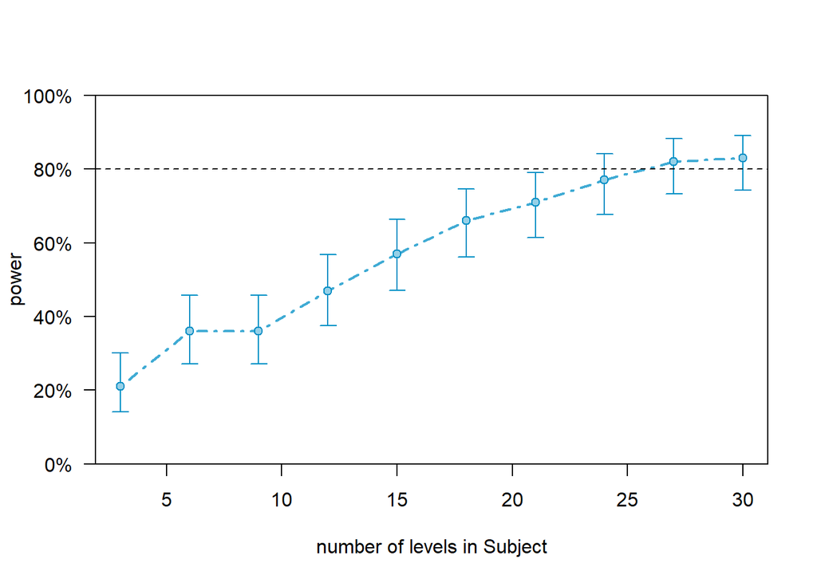

```r
# visualize results
plot(pc3)
```

Finally, it may be an option to increase the number of data points within subjects and items (while the number of items and subjects remain constant).

```r
m4 <- extend(m1, within="Item+Subject", n=15)
# perform power calculation
pc4 <- powerCurve(m4, fixed("ConditionTest", "z"), within="Item+Subject", breaks=c(5, 10, 15), nsim=100)
```

The results are shown below.

```r
# show results
print(pc4)
```

```
## Power for predictor 'ConditionTest', (95% confidence interval),
## by number of observations within Item+Subject:
##       5: 74.00% (64.27, 82.26) - 500 rows
##      10: 97.00% (91.48, 99.38) - 1000 rows
##      15: 100.0% (96.38, 100.0) - 1500 rows
##
## Time elapsed: 0 h 1 m 44 s
```

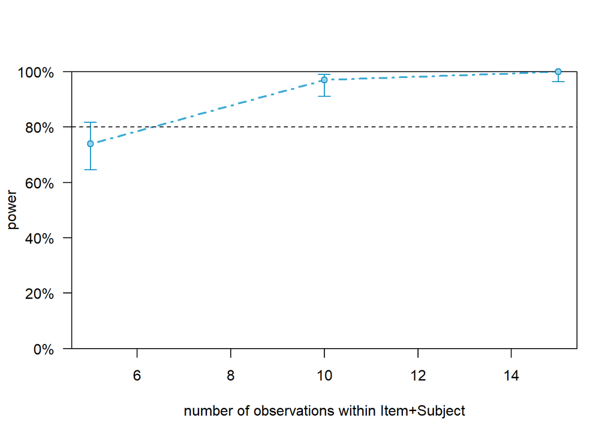

```r
# show results
plot(pc4)
```

# Wrap-up

That’s all folks!

# Citation & Session Info

Schweinberger, Martin. 2022. *Introduction to Data Visualization with R - AcqVA Aurora workshop*. Tromsø: The Arctic University of Norway, Tromsø. url: https://slcladal.github.io/introviz.html (Version 2022.01.20).

```
@manual{schweinberger2022acqvavizrws,
  author = {Schweinberger, Martin},
  title = {Introduction to Data Visualization with R - AcqVA Aurora workshop},
  note = {https://slcladal.github.io/introviz.html},
  year = {2022},
  organization = "The Arctic University of Norway (UiT), AcqVA Aurora Center},
  address = {Tromsø},
  edition = {2022.01.20}
}
```

Back to top

# References

Arnold, Benjamin F, Daniel R Hogan, John M Colford, and Alan E Hubbard. 2011. “Simulation Methods to Estimate Design Power: An Overview for Applied Research.” *BMC Medical Research Methodology* 11 (1): 1–10.

Bolker, Benjamin M, Mollie E Brooks, Connie J Clark, Shane W Geange, John R Poulsen, M Henry H Stevens, and Jada-Simone S White. 2009. “Generalized Linear Mixed Models: A Practical Guide for Ecology and Evolution.” *Trends in Ecology & Evolution* 24 (3): 127–35.

Chen, Henian, Patricia Cohen, and Sophie Chen. 2010. “How Big Is a Big Odds Ratio? Interpreting the Magnitudes of Odds Ratios in Epidemiological Studies.” *Communications in Statistics–Simulation and Computation* 39 (4): 860–64.

Field, Andy, Jeremy Miles, and Zoe Field. 2012. *Discovering Statistics Using R*. Sage.

Field, Scott A, Patrick J O’Connor, Andrew J Tyre, and Hugh P Possingham. 2007. “Making Monitoring Meaningful.” *Austral Ecology* 32 (5): 485–91.

Green, Peter, and Catriona J. MacLeod. 2016a. “Simr: An R Package for Power Analysis of Generalised Linear Mixed Models by Simulation.” *Methods in Ecology and Evolution* 7 (4): 493–98. https://doi.org/10.1111/2041-210X.12504.

Green, Peter, and Catriona J MacLeod. 2016b. “SIMR: An R Package for Power Analysis of Generalized Linear Mixed Models by Simulation.” *Methods in Ecology and Evolution* 7 (4): 493–98.

Halekoh, Ulrich, Søren Højsgaard, and others. 2014. “A Kenward-Roger Approximation and Parametric Bootstrap Methods for Tests in Linear Mixed Models–the R Package Pbkrtest.” *Journal of Statistical Software* 59 (9): 1–30.

Hoenig, John M, and Dennis M Heisey. 2001. “The Abuse of Power: The Pervasive Fallacy of Power Calculations for Data Analysis.” *The American Statistician* 55 (1): 19–24.

Johnson, Paul CD, Sarah JE Barry, Heather M Ferguson, and Pie Müller. 2015. “Power Analysis for Generalized Linear Mixed Models in Ecology and Evolution.” *Methods in Ecology and Evolution* 6 (2): 133–42.

Perugini, Marco, Marcello Gallucci, and Giulio Costantini. 2018. “A Practical Primer to Power Analysis for Simple Experimental Designs.” *International Review of Social Psychology* 31 (1): 1–23.